# Week-5 Tutorial

Bibek Sapkota

# Data Wrangling in R with dplyr tutorial

task 1: Install and Load the packages

```r
packages_to_install <- c("tidyverse")

for (package_name in packages_to_install) {
  if (!requireNamespace(package_name, quietly = TRUE)) {
    install.packages(package_name)
  }
}

library(tidyverse)
```

task 2:Displaying the dataset

```r
starwars
```

| name | height | mass | hair_color | skin_color | eye_color | birth_year | sex | gender | homeworld | species | films | vehicles | starships |
| --- | --- | --- | --- | --- | --- | --- | --- | --- | --- | --- | --- | --- | --- |
| Luke Skywalker | 172 | 77.0 | blond | fair | blue | 19.0 | male | masculine | Tatooine | Human |  |  |  |
| C-3PO | 167 | 75.0 | NA | gold | yellow | 112.0 | none | masculine | Tatooine | Droid |  |  |  |
| R2-D2 | 96 | 32.0 | NA | white, blue | red | 33.0 | none | masculine | Naboo | Droid |  |  |  |
| Darth Vader | 202 | 136.0 | none | white | yellow | 41.9 | male | masculine | Tatooine | Human |  |  |  |
| Leia Organa | 150 | 49.0 | brown | light | brown | 19.0 | female | feminine | Alderaan | Human |  |  |  |
| Owen Lars | 178 | 120.0 | brown, grey | light | blue | 52.0 | male | masculine | Tatooine | Human |  |  |  |
| Beru Whitesun Lars | 165 | 75.0 | brown | light | blue | 47.0 | female | feminine | Tatooine | Human |  |  |  |
| R5-D4 | 97 | 32.0 | NA | white, red | red | NA | none | masculine | Tatooine | Droid |  |  |  |
| Biggs Darklighter | 183 | 84.0 | black | light | brown | 24.0 | male | masculine | Tatooine | Human |  |  |  |
| Obi-Wan Kenobi | 182 | 77.0 | auburn, white | fair | blue-gray | 57.0 | male | masculine | Stewjon | Human |  |  |  |

[output cut: 77 more lines]

## dplyr syntax

task 1: Filter the data which have species Human.

```r
filter(starwars, species=="Human")
```

| name | height | mass | hair_color | skin_color | eye_color | birth_year | sex | gender | homeworld | species | films | vehicles | starships |
| --- | --- | --- | --- | --- | --- | --- | --- | --- | --- | --- | --- | --- | --- |
| Luke Skywalker | 172 | 77.0 | blond | fair | blue | 19.0 | male | masculine | Tatooine | Human |  |  |  |
| Darth Vader | 202 | 136.0 | none | white | yellow | 41.9 | male | masculine | Tatooine | Human |  |  |  |
| Leia Organa | 150 | 49.0 | brown | light | brown | 19.0 | female | feminine | Alderaan | Human |  |  |  |
| Owen Lars | 178 | 120.0 | brown, grey | light | blue | 52.0 | male | masculine | Tatooine | Human |  |  |  |
| Beru Whitesun Lars | 165 | 75.0 | brown | light | blue | 47.0 | female | feminine | Tatooine | Human |  |  |  |
| Biggs Darklighter | 183 | 84.0 | black | light | brown | 24.0 | male | masculine | Tatooine | Human |  |  |  |
| Obi-Wan Kenobi | 182 | 77.0 | auburn, white | fair | blue-gray | 57.0 | male | masculine | Stewjon | Human |  |  |  |
| Anakin Skywalker | 188 | 84.0 | blond | fair | blue | 41.9 | male | masculine | Tatooine | Human |  |  |  |
| Wilhuff Tarkin | 180 | NA | auburn, grey | fair | blue | 64.0 | male | masculine | Eriadu | Human |  |  |  |
| Han Solo | 180 | 80.0 | brown | fair | brown | 29.0 | male | masculine | Corellia | Human |  |  |  |

[output cut: 25 more lines]

```r
starwars[starwars$species=="Human"&!is.na(starwars$species),]
```

| name | height | mass | hair_color | skin_color | eye_color | birth_year | sex | gender | homeworld | species | films | vehicles | starships |
| --- | --- | --- | --- | --- | --- | --- | --- | --- | --- | --- | --- | --- | --- |
| Luke Skywalker | 172 | 77.0 | blond | fair | blue | 19.0 | male | masculine | Tatooine | Human |  |  |  |
| Darth Vader | 202 | 136.0 | none | white | yellow | 41.9 | male | masculine | Tatooine | Human |  |  |  |
| Leia Organa | 150 | 49.0 | brown | light | brown | 19.0 | female | feminine | Alderaan | Human |  |  |  |
| Owen Lars | 178 | 120.0 | brown, grey | light | blue | 52.0 | male | masculine | Tatooine | Human |  |  |  |
| Beru Whitesun Lars | 165 | 75.0 | brown | light | blue | 47.0 | female | feminine | Tatooine | Human |  |  |  |
| Biggs Darklighter | 183 | 84.0 | black | light | brown | 24.0 | male | masculine | Tatooine | Human |  |  |  |
| Obi-Wan Kenobi | 182 | 77.0 | auburn, white | fair | blue-gray | 57.0 | male | masculine | Stewjon | Human |  |  |  |
| Anakin Skywalker | 188 | 84.0 | blond | fair | blue | 41.9 | male | masculine | Tatooine | Human |  |  |  |
| Wilhuff Tarkin | 180 | NA | auburn, grey | fair | blue | 64.0 | male | masculine | Eriadu | Human |  |  |  |
| Han Solo | 180 | 80.0 | brown | fair | brown | 29.0 | male | masculine | Corellia | Human |  |  |  |

[output cut: 25 more lines]

## The pipe %>% operator

task 1:filtering the data by species Droid and then arrange it by its height

```r
filter(starwars,species=="Droid")%>%
  arrange(height)
```

| name | height | mass | hair_color | skin_color | eye_color | birth_year | sex | gender | homeworld | species | films | vehicles | starships |
| --- | --- | --- | --- | --- | --- | --- | --- | --- | --- | --- | --- | --- | --- |
| R2-D2 | 96 | 32 | NA | white, blue | red | 33 | none | masculine | Naboo | Droid |  |  |  |
| R4-P17 | 96 | NA | none | silver, red | red, blue | NA | none | feminine | NA | Droid |  |  |  |
| R5-D4 | 97 | 32 | NA | white, red | red | NA | none | masculine | Tatooine | Droid |  |  |  |
| C-3PO | 167 | 75 | NA | gold | yellow | 112 | none | masculine | Tatooine | Droid |  |  |  |
| IG-88 | 200 | 140 | none | metal | red | 15 | none | masculine | NA | Droid |  |  |  |
| BB8 | NA | NA | none | none | black | NA | none | masculine | NA | Droid |  |  |  |

task 2:Filtering the data by species and displaying it

```r
#Both are same but different ways of writing
filter(starwars, species=="Human")
```

| name | height | mass | hair_color | skin_color | eye_color | birth_year | sex | gender | homeworld | species | films | vehicles | starships |
| --- | --- | --- | --- | --- | --- | --- | --- | --- | --- | --- | --- | --- | --- |
| Luke Skywalker | 172 | 77.0 | blond | fair | blue | 19.0 | male | masculine | Tatooine | Human |  |  |  |
| Darth Vader | 202 | 136.0 | none | white | yellow | 41.9 | male | masculine | Tatooine | Human |  |  |  |
| Leia Organa | 150 | 49.0 | brown | light | brown | 19.0 | female | feminine | Alderaan | Human |  |  |  |
| Owen Lars | 178 | 120.0 | brown, grey | light | blue | 52.0 | male | masculine | Tatooine | Human |  |  |  |
| Beru Whitesun Lars | 165 | 75.0 | brown | light | blue | 47.0 | female | feminine | Tatooine | Human |  |  |  |
| Biggs Darklighter | 183 | 84.0 | black | light | brown | 24.0 | male | masculine | Tatooine | Human |  |  |  |
| Obi-Wan Kenobi | 182 | 77.0 | auburn, white | fair | blue-gray | 57.0 | male | masculine | Stewjon | Human |  |  |  |
| Anakin Skywalker | 188 | 84.0 | blond | fair | blue | 41.9 | male | masculine | Tatooine | Human |  |  |  |
| Wilhuff Tarkin | 180 | NA | auburn, grey | fair | blue | 64.0 | male | masculine | Eriadu | Human |  |  |  |
| Han Solo | 180 | 80.0 | brown | fair | brown | 29.0 | male | masculine | Corellia | Human |  |  |  |

[output cut: 25 more lines]

```r
starwars%>%filter(species=="Human")
```

| name | height | mass | hair_color | skin_color | eye_color | birth_year | sex | gender | homeworld | species | films | vehicles | starships |
| --- | --- | --- | --- | --- | --- | --- | --- | --- | --- | --- | --- | --- | --- |
| Luke Skywalker | 172 | 77.0 | blond | fair | blue | 19.0 | male | masculine | Tatooine | Human |  |  |  |
| Darth Vader | 202 | 136.0 | none | white | yellow | 41.9 | male | masculine | Tatooine | Human |  |  |  |
| Leia Organa | 150 | 49.0 | brown | light | brown | 19.0 | female | feminine | Alderaan | Human |  |  |  |
| Owen Lars | 178 | 120.0 | brown, grey | light | blue | 52.0 | male | masculine | Tatooine | Human |  |  |  |
| Beru Whitesun Lars | 165 | 75.0 | brown | light | blue | 47.0 | female | feminine | Tatooine | Human |  |  |  |
| Biggs Darklighter | 183 | 84.0 | black | light | brown | 24.0 | male | masculine | Tatooine | Human |  |  |  |
| Obi-Wan Kenobi | 182 | 77.0 | auburn, white | fair | blue-gray | 57.0 | male | masculine | Stewjon | Human |  |  |  |
| Anakin Skywalker | 188 | 84.0 | blond | fair | blue | 41.9 | male | masculine | Tatooine | Human |  |  |  |
| Wilhuff Tarkin | 180 | NA | auburn, grey | fair | blue | 64.0 | male | masculine | Eriadu | Human |  |  |  |
| Han Solo | 180 | 80.0 | brown | fair | brown | 29.0 | male | masculine | Corellia | Human |  |  |  |

[output cut: 25 more lines]

```r
starwars%>%
  filter(species=="Human")
```

| name | height | mass | hair_color | skin_color | eye_color | birth_year | sex | gender | homeworld | species | films | vehicles | starships |
| --- | --- | --- | --- | --- | --- | --- | --- | --- | --- | --- | --- | --- | --- |
| Luke Skywalker | 172 | 77.0 | blond | fair | blue | 19.0 | male | masculine | Tatooine | Human |  |  |  |
| Darth Vader | 202 | 136.0 | none | white | yellow | 41.9 | male | masculine | Tatooine | Human |  |  |  |
| Leia Organa | 150 | 49.0 | brown | light | brown | 19.0 | female | feminine | Alderaan | Human |  |  |  |
| Owen Lars | 178 | 120.0 | brown, grey | light | blue | 52.0 | male | masculine | Tatooine | Human |  |  |  |
| Beru Whitesun Lars | 165 | 75.0 | brown | light | blue | 47.0 | female | feminine | Tatooine | Human |  |  |  |
| Biggs Darklighter | 183 | 84.0 | black | light | brown | 24.0 | male | masculine | Tatooine | Human |  |  |  |
| Obi-Wan Kenobi | 182 | 77.0 | auburn, white | fair | blue-gray | 57.0 | male | masculine | Stewjon | Human |  |  |  |
| Anakin Skywalker | 188 | 84.0 | blond | fair | blue | 41.9 | male | masculine | Tatooine | Human |  |  |  |
| Wilhuff Tarkin | 180 | NA | auburn, grey | fair | blue | 64.0 | male | masculine | Eriadu | Human |  |  |  |
| Han Solo | 180 | 80.0 | brown | fair | brown | 29.0 | male | masculine | Corellia | Human |  |  |  |

[output cut: 25 more lines]

## Selecting columns with select()

task 1:Using dplyr’s glimpse() function to get a quick look at our data

```r
glimpse(starwars)
```

```
Rows: 87
Columns: 14
$ name       <chr> "Luke Skywalker", "C-3PO", "R2-D2", "Darth Vader", "Leia Organa", "Owen Lars", "Beru Whit…
$ height     <int> 172, 167, 96, 202, 150, 178, 165, 97, 183, 182, 188, 180, 228, 180, 173, 175, 170, 180, 6…
$ mass       <dbl> 77.0, 75.0, 32.0, 136.0, 49.0, 120.0, 75.0, 32.0, 84.0, 77.0, 84.0, NA, 112.0, 80.0, 74.0…
$ hair_color <chr> "blond", NA, NA, "none", "brown", "brown, grey", "brown", NA, "black", "auburn, white", "…
$ skin_color <chr> "fair", "gold", "white, blue", "white", "light", "light", "light", "white, red", "light",…
$ eye_color  <chr> "blue", "yellow", "red", "yellow", "brown", "blue", "blue", "red", "brown", "blue-gray", …
$ birth_year <dbl> 19.0, 112.0, 33.0, 41.9, 19.0, 52.0, 47.0, NA, 24.0, 57.0, 41.9, 64.0, 200.0, 29.0, 44.0,…
$ sex        <chr> "male", "none", "none", "male", "female", "male", "female", "none", "male", "male", "male…
$ gender     <chr> "masculine", "masculine", "masculine", "masculine", "feminine", "masculine", "feminine", …
$ homeworld  <chr> "Tatooine", "Tatooine", "Naboo", "Tatooine", "Alderaan", "Tatooine", "Tatooine", "Tatooin…
$ species    <chr> "Human", "Droid", "Droid", "Human", "Human", "Human", "Human", "Droid", "Human", "Human",…
$ films      <list> <"A New Hope", "The Empire Strikes Back", "Return of the Jedi", "Revenge of the Sith", "…
$ vehicles   <list> <"Snowspeeder", "Imperial Speeder Bike">, <>, <>, <>, "Imperial Speeder Bike", <>, <>, <…
$ starships  <list> <"X-wing", "Imperial shuttle">, <>, <>, "TIE Advanced x1", <>, <>, <>, <>, "X-wing", <"J…
```

task 2:Displaying only selected columns

```r
starwars %>%
    select(name,    height, mass,   hair_color, skin_color,
               eye_color,   birth_year, sex, gender,    homeworld,  species)
```

| name | height | mass | hair_color | skin_color | eye_color | birth_year | sex | gender | homeworld | species |
| --- | --- | --- | --- | --- | --- | --- | --- | --- | --- | --- |
| Luke Skywalker | 172 | 77.0 | blond | fair | blue | 19.0 | male | masculine | Tatooine | Human |
| C-3PO | 167 | 75.0 | NA | gold | yellow | 112.0 | none | masculine | Tatooine | Droid |
| R2-D2 | 96 | 32.0 | NA | white, blue | red | 33.0 | none | masculine | Naboo | Droid |
| Darth Vader | 202 | 136.0 | none | white | yellow | 41.9 | male | masculine | Tatooine | Human |
| Leia Organa | 150 | 49.0 | brown | light | brown | 19.0 | female | feminine | Alderaan | Human |
| Owen Lars | 178 | 120.0 | brown, grey | light | blue | 52.0 | male | masculine | Tatooine | Human |
| Beru Whitesun Lars | 165 | 75.0 | brown | light | blue | 47.0 | female | feminine | Tatooine | Human |
| R5-D4 | 97 | 32.0 | NA | white, red | red | NA | none | masculine | Tatooine | Droid |
| Biggs Darklighter | 183 | 84.0 | black | light | brown | 24.0 | male | masculine | Tatooine | Human |
| Obi-Wan Kenobi | 182 | 77.0 | auburn, white | fair | blue-gray | 57.0 | male | masculine | Stewjon | Human |

[output cut: 77 more lines]

task 3: Removing the selected columns

```r
starwars %>% select(-films, -vehicles, -starships)
```

| name | height | mass | hair_color | skin_color | eye_color | birth_year | sex | gender | homeworld | species |
| --- | --- | --- | --- | --- | --- | --- | --- | --- | --- | --- |
| Luke Skywalker | 172 | 77.0 | blond | fair | blue | 19.0 | male | masculine | Tatooine | Human |
| C-3PO | 167 | 75.0 | NA | gold | yellow | 112.0 | none | masculine | Tatooine | Droid |
| R2-D2 | 96 | 32.0 | NA | white, blue | red | 33.0 | none | masculine | Naboo | Droid |
| Darth Vader | 202 | 136.0 | none | white | yellow | 41.9 | male | masculine | Tatooine | Human |
| Leia Organa | 150 | 49.0 | brown | light | brown | 19.0 | female | feminine | Alderaan | Human |
| Owen Lars | 178 | 120.0 | brown, grey | light | blue | 52.0 | male | masculine | Tatooine | Human |
| Beru Whitesun Lars | 165 | 75.0 | brown | light | blue | 47.0 | female | feminine | Tatooine | Human |
| R5-D4 | 97 | 32.0 | NA | white, red | red | NA | none | masculine | Tatooine | Droid |
| Biggs Darklighter | 183 | 84.0 | black | light | brown | 24.0 | male | masculine | Tatooine | Human |
| Obi-Wan Kenobi | 182 | 77.0 | auburn, white | fair | blue-gray | 57.0 | male | masculine | Stewjon | Human |

[output cut: 77 more lines]

task 4:Displaying the table from name to species

```r
starwars%>%select(name:species)
```

| name | height | mass | hair_color | skin_color | eye_color | birth_year | sex | gender | homeworld | species |
| --- | --- | --- | --- | --- | --- | --- | --- | --- | --- | --- |
| Luke Skywalker | 172 | 77.0 | blond | fair | blue | 19.0 | male | masculine | Tatooine | Human |
| C-3PO | 167 | 75.0 | NA | gold | yellow | 112.0 | none | masculine | Tatooine | Droid |
| R2-D2 | 96 | 32.0 | NA | white, blue | red | 33.0 | none | masculine | Naboo | Droid |
| Darth Vader | 202 | 136.0 | none | white | yellow | 41.9 | male | masculine | Tatooine | Human |
| Leia Organa | 150 | 49.0 | brown | light | brown | 19.0 | female | feminine | Alderaan | Human |
| Owen Lars | 178 | 120.0 | brown, grey | light | blue | 52.0 | male | masculine | Tatooine | Human |
| Beru Whitesun Lars | 165 | 75.0 | brown | light | blue | 47.0 | female | feminine | Tatooine | Human |
| R5-D4 | 97 | 32.0 | NA | white, red | red | NA | none | masculine | Tatooine | Droid |
| Biggs Darklighter | 183 | 84.0 | black | light | brown | 24.0 | male | masculine | Tatooine | Human |
| Obi-Wan Kenobi | 182 | 77.0 | auburn, white | fair | blue-gray | 57.0 | male | masculine | Stewjon | Human |

[output cut: 77 more lines]

## Rename your columns with rename()

task 1:Renaming name columns to username

```r
starwars%>%
  rename(username=name)
```

| username | height | mass | hair_color | skin_color | eye_color | birth_year | sex | gender | homeworld | species | films | vehicles | starships |
| --- | --- | --- | --- | --- | --- | --- | --- | --- | --- | --- | --- | --- | --- |
| Luke Skywalker | 172 | 77.0 | blond | fair | blue | 19.0 | male | masculine | Tatooine | Human |  |  |  |
| C-3PO | 167 | 75.0 | NA | gold | yellow | 112.0 | none | masculine | Tatooine | Droid |  |  |  |
| R2-D2 | 96 | 32.0 | NA | white, blue | red | 33.0 | none | masculine | Naboo | Droid |  |  |  |
| Darth Vader | 202 | 136.0 | none | white | yellow | 41.9 | male | masculine | Tatooine | Human |  |  |  |
| Leia Organa | 150 | 49.0 | brown | light | brown | 19.0 | female | feminine | Alderaan | Human |  |  |  |
| Owen Lars | 178 | 120.0 | brown, grey | light | blue | 52.0 | male | masculine | Tatooine | Human |  |  |  |
| Beru Whitesun Lars | 165 | 75.0 | brown | light | blue | 47.0 | female | feminine | Tatooine | Human |  |  |  |
| R5-D4 | 97 | 32.0 | NA | white, red | red | NA | none | masculine | Tatooine | Droid |  |  |  |
| Biggs Darklighter | 183 | 84.0 | black | light | brown | 24.0 | male | masculine | Tatooine | Human |  |  |  |
| Obi-Wan Kenobi | 182 | 77.0 | auburn, white | fair | blue-gray | 57.0 | male | masculine | Stewjon | Human |  |  |  |

[output cut: 77 more lines]

task 2:Displaying the data and then renaming the height column

```r
starwars%>%
  select(name:species)%>%
  rename(height_cm=height)
```

| name | height_cm | mass | hair_color | skin_color | eye_color | birth_year | sex | gender | homeworld | species |
| --- | --- | --- | --- | --- | --- | --- | --- | --- | --- | --- |
| Luke Skywalker | 172 | 77.0 | blond | fair | blue | 19.0 | male | masculine | Tatooine | Human |
| C-3PO | 167 | 75.0 | NA | gold | yellow | 112.0 | none | masculine | Tatooine | Droid |
| R2-D2 | 96 | 32.0 | NA | white, blue | red | 33.0 | none | masculine | Naboo | Droid |
| Darth Vader | 202 | 136.0 | none | white | yellow | 41.9 | male | masculine | Tatooine | Human |
| Leia Organa | 150 | 49.0 | brown | light | brown | 19.0 | female | feminine | Alderaan | Human |
| Owen Lars | 178 | 120.0 | brown, grey | light | blue | 52.0 | male | masculine | Tatooine | Human |
| Beru Whitesun Lars | 165 | 75.0 | brown | light | blue | 47.0 | female | feminine | Tatooine | Human |
| R5-D4 | 97 | 32.0 | NA | white, red | red | NA | none | masculine | Tatooine | Droid |
| Biggs Darklighter | 183 | 84.0 | black | light | brown | 24.0 | male | masculine | Tatooine | Human |
| Obi-Wan Kenobi | 182 | 77.0 | auburn, white | fair | blue-gray | 57.0 | male | masculine | Stewjon | Human |

[output cut: 77 more lines]

## Sort a data with arrange()

task 1:Loading the data

```r
starwars
```

| name | height | mass | hair_color | skin_color | eye_color | birth_year | sex | gender | homeworld | species | films | vehicles | starships |
| --- | --- | --- | --- | --- | --- | --- | --- | --- | --- | --- | --- | --- | --- |
| Luke Skywalker | 172 | 77.0 | blond | fair | blue | 19.0 | male | masculine | Tatooine | Human |  |  |  |
| C-3PO | 167 | 75.0 | NA | gold | yellow | 112.0 | none | masculine | Tatooine | Droid |  |  |  |
| R2-D2 | 96 | 32.0 | NA | white, blue | red | 33.0 | none | masculine | Naboo | Droid |  |  |  |
| Darth Vader | 202 | 136.0 | none | white | yellow | 41.9 | male | masculine | Tatooine | Human |  |  |  |
| Leia Organa | 150 | 49.0 | brown | light | brown | 19.0 | female | feminine | Alderaan | Human |  |  |  |
| Owen Lars | 178 | 120.0 | brown, grey | light | blue | 52.0 | male | masculine | Tatooine | Human |  |  |  |
| Beru Whitesun Lars | 165 | 75.0 | brown | light | blue | 47.0 | female | feminine | Tatooine | Human |  |  |  |
| R5-D4 | 97 | 32.0 | NA | white, red | red | NA | none | masculine | Tatooine | Droid |  |  |  |
| Biggs Darklighter | 183 | 84.0 | black | light | brown | 24.0 | male | masculine | Tatooine | Human |  |  |  |
| Obi-Wan Kenobi | 182 | 77.0 | auburn, white | fair | blue-gray | 57.0 | male | masculine | Stewjon | Human |  |  |  |

[output cut: 77 more lines]

task 2:Diaplaying the data from name to mass and arrange it by height

```r
starwars %>%
  select(name:mass) %>%
  arrange(height)
```

| name | height | mass |
| --- | --- | --- |
| Yoda | 66 | 17.0 |
| Ratts Tyerel | 79 | 15.0 |
| Wicket Systri Warrick | 88 | 20.0 |
| Dud Bolt | 94 | 45.0 |
| R2-D2 | 96 | 32.0 |
| R4-P17 | 96 | NA |
| R5-D4 | 97 | 32.0 |
| Sebulba | 112 | 40.0 |
| Gasgano | 122 | NA |
| Watto | 137 | NA |

[output cut: 77 more lines]

task 3:Arranging the height columns in descending order

```r
starwars%>%
  select(name:mass)%>%
  arrange(desc(height))
```

| name | height | mass |
| --- | --- | --- |
| Yarael Poof | 264 | NA |
| Tarfful | 234 | 136.0 |
| Lama Su | 229 | 88.0 |
| Chewbacca | 228 | 112.0 |
| Roos Tarpals | 224 | 82.0 |
| Grievous | 216 | 159.0 |
| Taun We | 213 | NA |
| Rugor Nass | 206 | NA |
| Tion Medon | 206 | 80.0 |
| Darth Vader | 202 | 136.0 |

[output cut: 77 more lines]

task 4:Arranging the columns first by homeworld columns and then by height

```r
starwars %>%
  select(name, homeworld, height) %>%
  arrange(homeworld, desc(height))
```

| name | homeworld | height |
| --- | --- | --- |
| Bail Prestor Organa | Alderaan | 191 |
| Raymus Antilles | Alderaan | 188 |
| Leia Organa | Alderaan | 150 |
| Ratts Tyerel | Aleen Minor | 79 |
| Lobot | Bespin | 175 |
| Jek Tono Porkins | Bestine IV | 180 |
| Nute Gunray | Cato Neimoidia | 191 |
| Ki-Adi-Mundi | Cerea | 198 |
| Mas Amedda | Champala | 196 |
| Mon Mothma | Chandrila | 150 |

[output cut: 77 more lines]

## Select rows based on their position using slice()

task 1:Displaying first 3 rows of the data from name to mass

```r
starwars%>%
  slice(1:3)%>%
  select(name:mass)
```

| name | height | mass |
| --- | --- | --- |
| Luke Skywalker | 172 | 77 |
| C-3PO | 167 | 75 |
| R2-D2 | 96 | 32 |

task 2: Arraning the data by height then displaying 1st 3 rows from name to mass

```r
starwars%>%
  arrange(height)%>%
  slice(1:3)%>%
  select(name:mass)
```

| name | height | mass |
| --- | --- | --- |
| Yoda | 66 | 17 |
| Ratts Tyerel | 79 | 15 |
| Wicket Systri Warrick | 88 | 20 |

## Subset your data with filter()

task 1:using filter() to filter species and homeworld

```r
starwars %>%
  select(name, species, homeworld, height, mass, birth_year) %>%
  filter(species=="Human" & homeworld=="Tatooine")
```

| name | species | homeworld | height | mass | birth_year |
| --- | --- | --- | --- | --- | --- |
| Luke Skywalker | Human | Tatooine | 172 | 77 | 19.0 |
| Darth Vader | Human | Tatooine | 202 | 136 | 41.9 |
| Owen Lars | Human | Tatooine | 178 | 120 | 52.0 |
| Beru Whitesun Lars | Human | Tatooine | 165 | 75 | 47.0 |
| Biggs Darklighter | Human | Tatooine | 183 | 84 | 24.0 |
| Anakin Skywalker | Human | Tatooine | 188 | 84 | 41.9 |
| Shmi Skywalker | Human | Tatooine | 163 | NA | 72.0 |
| Cliegg Lars | Human | Tatooine | 183 | NA | 82.0 |

task 2:Using comma(,) in & operator

```r
starwars %>%
  select(name, species, homeworld, height, mass, birth_year) %>%
  filter(species=="Human", homeworld=="Tatooine")
```

| name | species | homeworld | height | mass | birth_year |
| --- | --- | --- | --- | --- | --- |
| Luke Skywalker | Human | Tatooine | 172 | 77 | 19.0 |
| Darth Vader | Human | Tatooine | 202 | 136 | 41.9 |
| Owen Lars | Human | Tatooine | 178 | 120 | 52.0 |
| Beru Whitesun Lars | Human | Tatooine | 165 | 75 | 47.0 |
| Biggs Darklighter | Human | Tatooine | 183 | 84 | 24.0 |
| Anakin Skywalker | Human | Tatooine | 188 | 84 | 41.9 |
| Shmi Skywalker | Human | Tatooine | 163 | NA | 72.0 |
| Cliegg Lars | Human | Tatooine | 183 | NA | 82.0 |

task 3:Using ‘|’ if we wanted characters that are either Humans or Droids to represent ‘or’

```r
starwars %>%
  select(name, species, homeworld, height, mass, birth_year) %>%
  filter(species=="Human" | species=="Droid")
```

| name | species | homeworld | height | mass | birth_year |
| --- | --- | --- | --- | --- | --- |
| Luke Skywalker | Human | Tatooine | 172 | 77.0 | 19.0 |
| C-3PO | Droid | Tatooine | 167 | 75.0 | 112.0 |
| R2-D2 | Droid | Naboo | 96 | 32.0 | 33.0 |
| Darth Vader | Human | Tatooine | 202 | 136.0 | 41.9 |
| Leia Organa | Human | Alderaan | 150 | 49.0 | 19.0 |
| Owen Lars | Human | Tatooine | 178 | 120.0 | 52.0 |
| Beru Whitesun Lars | Human | Tatooine | 165 | 75.0 | 47.0 |
| R5-D4 | Droid | Tatooine | 97 | 32.0 | NA |
| Biggs Darklighter | Human | Tatooine | 183 | 84.0 | 24.0 |
| Obi-Wan Kenobi | Human | Stewjon | 182 | 77.0 | 57.0 |

[output cut: 31 more lines]

task 4: rewriting above code using %in% in place of |

```r
starwars %>%
  select(name, species, homeworld, height, mass, birth_year) %>%
  filter(species %in% c("Human", "Droid"))
```

| name | species | homeworld | height | mass | birth_year |
| --- | --- | --- | --- | --- | --- |
| Luke Skywalker | Human | Tatooine | 172 | 77.0 | 19.0 |
| C-3PO | Droid | Tatooine | 167 | 75.0 | 112.0 |
| R2-D2 | Droid | Naboo | 96 | 32.0 | 33.0 |
| Darth Vader | Human | Tatooine | 202 | 136.0 | 41.9 |
| Leia Organa | Human | Alderaan | 150 | 49.0 | 19.0 |
| Owen Lars | Human | Tatooine | 178 | 120.0 | 52.0 |
| Beru Whitesun Lars | Human | Tatooine | 165 | 75.0 | 47.0 |
| R5-D4 | Droid | Tatooine | 97 | 32.0 | NA |
| Biggs Darklighter | Human | Tatooine | 183 | 84.0 | 24.0 |
| Obi-Wan Kenobi | Human | Stewjon | 182 | 77.0 | 57.0 |

[output cut: 31 more lines]

task 5:Printing birthyear of 15,19 and 21 using %in% operator

```r
starwars %>%
  select(name, species, homeworld, height,  mass, birth_year) %>%
  filter(birth_year %in% c(15, 19, 21))
```

| name | species | homeworld | height | mass | birth_year |
| --- | --- | --- | --- | --- | --- |
| Luke Skywalker | Human | Tatooine | 172 | 77 | 19 |
| Leia Organa | Human | Alderaan | 150 | 49 | 19 |
| Wedge Antilles | Human | Corellia | 170 | 77 | 21 |
| IG-88 | Droid | NA | 200 | 140 | 15 |

## Making robust filters with pull()

task 1:Filtering using name

```r
starwars %>%
  filter(name %in% c("C-3PO", "R2-D2", "R5-D4"))
```

| name | height | mass | hair_color | skin_color | eye_color | birth_year | sex | gender | homeworld | species | films | vehicles | starships |
| --- | --- | --- | --- | --- | --- | --- | --- | --- | --- | --- | --- | --- | --- |
| C-3PO | 167 | 75 | NA | gold | yellow | 112 | none | masculine | Tatooine | Droid |  |  |  |
| R2-D2 | 96 | 32 | NA | white, blue | red | 33 | none | masculine | Naboo | Droid |  |  |  |
| R5-D4 | 97 | 32 | NA | white, red | red | NA | none | masculine | Tatooine | Droid |  |  |  |

```r
starwars %>%
  filter(name %in% c("C-3PO", "R2-D2", "R5-D4", "IG-88"))
```

| name | height | mass | hair_color | skin_color | eye_color | birth_year | sex | gender | homeworld | species | films | vehicles | starships |
| --- | --- | --- | --- | --- | --- | --- | --- | --- | --- | --- | --- | --- | --- |
| C-3PO | 167 | 75 | NA | gold | yellow | 112 | none | masculine | Tatooine | Droid |  |  |  |
| R2-D2 | 96 | 32 | NA | white, blue | red | 33 | none | masculine | Naboo | Droid |  |  |  |
| R5-D4 | 97 | 32 | NA | white, red | red | NA | none | masculine | Tatooine | Droid |  |  |  |
| IG-88 | 200 | 140 | none | metal | red | 15 | none | masculine | NA | Droid |  |  |  |

task 2:Filtering species

```r
starwars %>%
  filter(species=="Droid")
```

| name | height | mass | hair_color | skin_color | eye_color | birth_year | sex | gender | homeworld | species | films | vehicles | starships |
| --- | --- | --- | --- | --- | --- | --- | --- | --- | --- | --- | --- | --- | --- |
| C-3PO | 167 | 75 | NA | gold | yellow | 112 | none | masculine | Tatooine | Droid |  |  |  |
| R2-D2 | 96 | 32 | NA | white, blue | red | 33 | none | masculine | Naboo | Droid |  |  |  |
| R5-D4 | 97 | 32 | NA | white, red | red | NA | none | masculine | Tatooine | Droid |  |  |  |
| IG-88 | 200 | 140 | none | metal | red | 15 | none | masculine | NA | Droid |  |  |  |
| R4-P17 | 96 | NA | none | silver, red | red, blue | NA | none | feminine | NA | Droid |  |  |  |
| BB8 | NA | NA | none | none | black | NA | none | masculine | NA | Droid |  |  |  |

task 3:Using pull() by passing it a data set and a column=name and it ‘pulls’ all the values into a vector

```r
starwars %>%
  pull(name)
```

```
 [1] "Luke Skywalker"        "C-3PO"                 "R2-D2"                 "Darth Vader"
 [5] "Leia Organa"           "Owen Lars"             "Beru Whitesun Lars"    "R5-D4"
 [9] "Biggs Darklighter"     "Obi-Wan Kenobi"        "Anakin Skywalker"      "Wilhuff Tarkin"
[13] "Chewbacca"             "Han Solo"              "Greedo"                "Jabba Desilijic Tiure"
[17] "Wedge Antilles"        "Jek Tono Porkins"      "Yoda"                  "Palpatine"
[21] "Boba Fett"             "IG-88"                 "Bossk"                 "Lando Calrissian"
[25] "Lobot"                 "Ackbar"                "Mon Mothma"            "Arvel Crynyd"
[29] "Wicket Systri Warrick" "Nien Nunb"             "Qui-Gon Jinn"          "Nute Gunray"
[33] "Finis Valorum"         "Padmé Amidala"         "Jar Jar Binks"         "Roos Tarpals"
[37] "Rugor Nass"            "Ric Olié"              "Watto"                 "Sebulba"
[41] "Quarsh Panaka"         "Shmi Skywalker"        "Darth Maul"            "Bib Fortuna"
[45] "Ayla Secura"           "Ratts Tyerel"          "Dud Bolt"              "Gasgano"
[49] "Ben Quadinaros"        "Mace Windu"            "Ki-Adi-Mundi"          "Kit Fisto"
[53] "Eeth Koth"             "Adi Gallia"            "Saesee Tiin"           "Yarael Poof"
[57] "Plo Koon"              "Mas Amedda"            "Gregar Typho"          "Cordé"
[61] "Cliegg Lars"           "Poggle the Lesser"     "Luminara Unduli"       "Barriss Offee"
[65] "Dormé"                 "Dooku"                 "Bail Prestor Organa"   "Jango Fett"
[69] "Zam Wesell"            "Dexter Jettster"       "Lama Su"               "Taun We"
[73] "Jocasta Nu"            "R4-P17"                "Wat Tambor"            "San Hill"
[77] "Shaak Ti"              "Grievous"              "Tarfful"               "Raymus Antilles"
[81] "Sly Moore"             "Tion Medon"            "Finn"                  "Rey"
[85] "Poe Dameron"           "BB8"                   "Captain Phasma"
```

task 4:pulling(data set, column) so it knows where to pull the names from

```r
trending <- sample_n(starwars, 10) %>%
                    select(name)

starwars %>%
  select(name:species) %>%
  filter(name %in% pull(trending, name))
```

| name | height | mass | hair_color | skin_color | eye_color | birth_year | sex | gender | homeworld | species |
| --- | --- | --- | --- | --- | --- | --- | --- | --- | --- | --- |
| Owen Lars | 178 | 120 | brown, grey | light | blue | 52 | male | masculine | Tatooine | Human |
| Jabba Desilijic Tiure | 175 | 1358 | NA | green-tan, brown | orange | 600 | hermaphroditic | masculine | Nal Hutta | Hutt |
| IG-88 | 200 | 140 | none | metal | red | 15 | none | masculine | NA | Droid |
| Watto | 137 | NA | black | blue, grey | yellow | NA | male | masculine | Toydaria | Toydarian |
| Sebulba | 112 | 40 | none | grey, red | orange | NA | male | masculine | Malastare | Dug |
| Jango Fett | 183 | 79 | black | tan | brown | 66 | male | masculine | Concord Dawn | Human |
| Zam Wesell | 168 | 55 | blonde | fair, green, yellow | yellow | NA | female | feminine | Zolan | Clawdite |
| Dexter Jettster | 198 | 102 | none | brown | yellow | NA | male | masculine | Ojom | Besalisk |
| Lama Su | 229 | 88 | none | grey | black | NA | male | masculine | Kamino | Kaminoan |
| Captain Phasma | NA | NA | none | none | unknown | NA | female | feminine | NA | Human |

task 5:If we run the above code again we’ll get a different 10 random characters

```r
trending <- sample_n(starwars, 10) %>%
                    select(name)

starwars %>%
  select(name:species) %>%
  filter(name %in% pull(trending, name))
```

| name | height | mass | hair_color | skin_color | eye_color | birth_year | sex | gender | homeworld | species |
| --- | --- | --- | --- | --- | --- | --- | --- | --- | --- | --- |
| Biggs Darklighter | 183 | 84 | black | light | brown | 24 | male | masculine | Tatooine | Human |
| Jek Tono Porkins | 180 | 110 | brown | fair | blue | NA | NA | NA | Bestine IV | NA |
| Yoda | 66 | 17 | white | green | brown | 896 | male | masculine | NA | Yoda's species |
| Bossk | 190 | 113 | none | green | red | 53 | male | masculine | Trandosha | Trandoshan |
| Ackbar | 180 | 83 | none | brown mottle | orange | 41 | male | masculine | Mon Cala | Mon Calamari |
| Saesee Tiin | 188 | NA | none | pale | orange | NA | male | masculine | Iktotch | Iktotchi |
| Gregar Typho | 185 | 85 | black | dark | brown | NA | NA | NA | Naboo | NA |
| Cordé | 157 | NA | brown | light | brown | NA | NA | NA | Naboo | NA |
| Sly Moore | 178 | 48 | none | pale | white | NA | NA | NA | Umbara | NA |
| BB8 | NA | NA | none | none | black | NA | none | masculine | NA | Droid |

## Create new columns with mutate()

task 1:Creating new column usingmutate(new_column = something)

```r
starwars %>%
  select(name:mass) %>%
  mutate(BMI = mass/((height/100)^2))
```

| name | height | mass | BMI |
| --- | --- | --- | --- |
| Luke Skywalker | 172 | 77.0 | 26.02758 |
| C-3PO | 167 | 75.0 | 26.89232 |
| R2-D2 | 96 | 32.0 | 34.72222 |
| Darth Vader | 202 | 136.0 | 33.33007 |
| Leia Organa | 150 | 49.0 | 21.77778 |
| Owen Lars | 178 | 120.0 | 37.87401 |
| Beru Whitesun Lars | 165 | 75.0 | 27.54821 |
| R5-D4 | 97 | 32.0 | 34.00999 |
| Biggs Darklighter | 183 | 84.0 | 25.08286 |
| Obi-Wan Kenobi | 182 | 77.0 | 23.24598 |

[output cut: 77 more lines]

task 2:Converting height from cm into feet and weight from kg into pounds

```r
starwars %>%
  select(name:mass) %>%
  mutate(height_ft = height * 0.0328084,
              weight_pounds = mass*2.20462)
```

| name | height | mass | height_ft | weight_pounds |
| --- | --- | --- | --- | --- |
| Luke Skywalker | 172 | 77.0 | 5.643045 | 169.75574 |
| C-3PO | 167 | 75.0 | 5.479003 | 165.34650 |
| R2-D2 | 96 | 32.0 | 3.149606 | 70.54784 |
| Darth Vader | 202 | 136.0 | 6.627297 | 299.82832 |
| Leia Organa | 150 | 49.0 | 4.921260 | 108.02638 |
| Owen Lars | 178 | 120.0 | 5.839895 | 264.55440 |
| Beru Whitesun Lars | 165 | 75.0 | 5.413386 | 165.34650 |
| R5-D4 | 97 | 32.0 | 3.182415 | 70.54784 |
| Biggs Darklighter | 183 | 84.0 | 6.003937 | 185.18808 |
| Obi-Wan Kenobi | 182 | 77.0 | 5.971129 | 169.75574 |

[output cut: 77 more lines]

task 3:Using a simple yes/no test i.e. taller than 6ft or not we can do this with ifelse():

```r
starwars %>%
  select(name:mass ) %>%
  mutate(height_ft = height * 0.0328084,
         over_6ft = ifelse(height_ft>6, 1, 0))
```

| name | height | mass | height_ft | over_6ft |
| --- | --- | --- | --- | --- |
| Luke Skywalker | 172 | 77.0 | 5.643045 | 0 |
| C-3PO | 167 | 75.0 | 5.479003 | 0 |
| R2-D2 | 96 | 32.0 | 3.149606 | 0 |
| Darth Vader | 202 | 136.0 | 6.627297 | 1 |
| Leia Organa | 150 | 49.0 | 4.921260 | 0 |
| Owen Lars | 178 | 120.0 | 5.839895 | 0 |
| Beru Whitesun Lars | 165 | 75.0 | 5.413386 | 0 |
| R5-D4 | 97 | 32.0 | 3.182415 | 0 |
| Biggs Darklighter | 183 | 84.0 | 6.003937 | 1 |
| Obi-Wan Kenobi | 182 | 77.0 | 5.971129 | 0 |

[output cut: 77 more lines]

task 4:Using multiple logical conditions in our mutate

```r
starwars %>%
  select(name:mass ) %>%
  mutate(height_ft = height * 0.0328084,
               height_group = case_when(    is.na(height) ~ "Missing",
                                                height_ft<5   ~ "Under 5ft",
                                                height_ft>6   ~ "Over  6ft",
                                                TRUE  ~ "Between 5-6ft"))
```

| name | height | mass | height_ft | height_group |
| --- | --- | --- | --- | --- |
| Luke Skywalker | 172 | 77.0 | 5.643045 | Between 5-6ft |
| C-3PO | 167 | 75.0 | 5.479003 | Between 5-6ft |
| R2-D2 | 96 | 32.0 | 3.149606 | Under 5ft |
| Darth Vader | 202 | 136.0 | 6.627297 | Over 6ft |
| Leia Organa | 150 | 49.0 | 4.921260 | Under 5ft |
| Owen Lars | 178 | 120.0 | 5.839895 | Between 5-6ft |
| Beru Whitesun Lars | 165 | 75.0 | 5.413386 | Between 5-6ft |
| R5-D4 | 97 | 32.0 | 3.182415 | Under 5ft |
| Biggs Darklighter | 183 | 84.0 | 6.003937 | Over 6ft |
| Obi-Wan Kenobi | 182 | 77.0 | 5.971129 | Between 5-6ft |

[output cut: 77 more lines]

task 5:Displaying result what will come if we don’t use TRUE at last

```r
starwars %>%
  select(name:mass ) %>%
  mutate(height_ft = height * 0.0328084,
              height_group = case_when(is.na(height) ~ "Missing",
                                               height_ft<5   ~ "Under 5ft",
                                               height_ft>6   ~ "Over  6ft"))
```

| name | height | mass | height_ft | height_group |
| --- | --- | --- | --- | --- |
| Luke Skywalker | 172 | 77.0 | 5.643045 | NA |
| C-3PO | 167 | 75.0 | 5.479003 | NA |
| R2-D2 | 96 | 32.0 | 3.149606 | Under 5ft |
| Darth Vader | 202 | 136.0 | 6.627297 | Over 6ft |
| Leia Organa | 150 | 49.0 | 4.921260 | Under 5ft |
| Owen Lars | 178 | 120.0 | 5.839895 | NA |
| Beru Whitesun Lars | 165 | 75.0 | 5.413386 | NA |
| R5-D4 | 97 | 32.0 | 3.182415 | Under 5ft |
| Biggs Darklighter | 183 | 84.0 | 6.003937 | Over 6ft |
| Obi-Wan Kenobi | 182 | 77.0 | 5.971129 | NA |

[output cut: 77 more lines]

## Window functions with mutate()

task 1:creating new columns that contain summaries of data from within the table

```r
starwars %>%
  select(name:mass ) %>%
  mutate(avg_height = mean(height, na.rm=T))
```

| name | height | mass | avg_height |
| --- | --- | --- | --- |
| Luke Skywalker | 172 | 77.0 | 174.6049 |
| C-3PO | 167 | 75.0 | 174.6049 |
| R2-D2 | 96 | 32.0 | 174.6049 |
| Darth Vader | 202 | 136.0 | 174.6049 |
| Leia Organa | 150 | 49.0 | 174.6049 |
| Owen Lars | 178 | 120.0 | 174.6049 |
| Beru Whitesun Lars | 165 | 75.0 | 174.6049 |
| R5-D4 | 97 | 32.0 | 174.6049 |
| Biggs Darklighter | 183 | 84.0 | 174.6049 |
| Obi-Wan Kenobi | 182 | 77.0 | 174.6049 |

[output cut: 77 more lines]

task 2:Creating a new column that compares the individual height

```r
starwars %>%
  select(name:mass) %>%
  mutate( avg_height = mean(height, na.rm=T),
            height_index = height/avg_height,
             height_group=case_when(height_index<=.8  ~ "short",
                                                            height_index>=1.2 ~ "tall",
                                                    TRUE  ~ "average"))
```

| name | height | mass | avg_height | height_index | height_group |
| --- | --- | --- | --- | --- | --- |
| Luke Skywalker | 172 | 77.0 | 174.6049 | 0.9850810 | average |
| C-3PO | 167 | 75.0 | 174.6049 | 0.9564449 | average |
| R2-D2 | 96 | 32.0 | 174.6049 | 0.5498126 | short |
| Darth Vader | 202 | 136.0 | 174.6049 | 1.1568974 | average |
| Leia Organa | 150 | 49.0 | 174.6049 | 0.8590822 | average |
| Owen Lars | 178 | 120.0 | 174.6049 | 1.0194442 | average |
| Beru Whitesun Lars | 165 | 75.0 | 174.6049 | 0.9449905 | average |
| R5-D4 | 97 | 32.0 | 174.6049 | 0.5555398 | short |
| Biggs Darklighter | 183 | 84.0 | 174.6049 | 1.0480803 | average |
| Obi-Wan Kenobi | 182 | 77.0 | 174.6049 | 1.0423531 | average |

[output cut: 77 more lines]

task 3:Just using the calculation directly as part of our height_index formula

```r
starwars %>%
  select(name:mass) %>%
  mutate(height_group=case_when(height / mean(height, na.rm=T)<=.8  ~ "short",
                                                         height / mean(height, na.rm=T)>=1.2 ~ "tall",
                                                         TRUE  ~ "average"))
```

| name | height | mass | height_group |
| --- | --- | --- | --- |
| Luke Skywalker | 172 | 77.0 | average |
| C-3PO | 167 | 75.0 | average |
| R2-D2 | 96 | 32.0 | short |
| Darth Vader | 202 | 136.0 | average |
| Leia Organa | 150 | 49.0 | average |
| Owen Lars | 178 | 120.0 | average |
| Beru Whitesun Lars | 165 | 75.0 | average |
| R5-D4 | 97 | 32.0 | short |
| Biggs Darklighter | 183 | 84.0 | average |
| Obi-Wan Kenobi | 182 | 77.0 | average |

[output cut: 77 more lines]

## Aggregating data using summarise()

task 1:Using summarise to get average height of the data set:

```r
starwars %>%
  summarise(avg_height=mean(height, na.rm=T))
```

| avg_height |
| --- |
| 174.6049 |

task 2:Summarizing the data

```r
starwars %>%
  summarise(num_records=n(),                              # Number of records in the table
                 distinct_species=n_distinct(species), # Number of unique values of "species"
                     avg_mass=mean(mass, na.rm=T),             # Average mass excluding any missing values
                 median_mass=median(mass, na.rm=T),    # Median mass excluding any missing values
                 IQR_mass=IQR(mass, na.rm=T),     # The interquartile range for mass excluding any missing values
                 shortest=min(height, na.rm=T),        # Min value of height excluding any missing values
                     tallest=max(height, na.rm=T))          # Max value of height excluding any missing values
```

| num_records | distinct_species | avg_mass | median_mass | IQR_mass | shortest | tallest |
| --- | --- | --- | --- | --- | --- | --- |
| 87 | 38 | 97.31186 | 79 | 28.9 | 66 | 264 |

## dplyr + base R = conditional sums

task 1:Displaying species in dataset

```r
starwars$species
```

```
 [1] "Human"          "Droid"          "Droid"          "Human"          "Human"          "Human"
 [7] "Human"          "Droid"          "Human"          "Human"          "Human"          "Human"
[13] "Wookiee"        "Human"          "Rodian"         "Hutt"           "Human"          NA
[19] "Yoda's species" "Human"          "Human"          "Droid"          "Trandoshan"     "Human"
[25] "Human"          "Mon Calamari"   "Human"          "Human"          "Ewok"           "Sullustan"
[31] "Human"          "Neimodian"      "Human"          "Human"          "Gungan"         "Gungan"
[37] "Gungan"         "Human"          "Toydarian"      "Dug"            "Human"          "Human"
[43] "Zabrak"         "Twi'lek"        "Twi'lek"        "Aleena"         "Vulptereen"     "Xexto"
[49] "Toong"          "Human"          "Cerean"         "Nautolan"       "Zabrak"         "Tholothian"
[55] "Iktotchi"       "Quermian"       "Kel Dor"        "Chagrian"       NA               NA
[61] "Human"          "Geonosian"      "Mirialan"       "Mirialan"       "Human"          "Human"
[67] "Human"          "Human"          "Clawdite"       "Besalisk"       "Kaminoan"       "Kaminoan"
[73] "Human"          "Droid"          "Skakoan"        "Muun"           "Togruta"        "Kaleesh"
[79] "Wookiee"        "Human"          NA               "Pau'an"         "Human"          "Human"
[85] "Human"          "Droid"          "Human"
```

task 2:Applying a logical condition to it which turns our vector into a logical one

```r
starwars$species=="Human"
```

```
 [1]  TRUE FALSE FALSE  TRUE  TRUE  TRUE  TRUE FALSE  TRUE  TRUE  TRUE  TRUE FALSE  TRUE FALSE FALSE  TRUE
[18]    NA FALSE  TRUE  TRUE FALSE FALSE  TRUE  TRUE FALSE  TRUE  TRUE FALSE FALSE  TRUE FALSE  TRUE  TRUE
[35] FALSE FALSE FALSE  TRUE FALSE FALSE  TRUE  TRUE FALSE FALSE FALSE FALSE FALSE FALSE FALSE  TRUE FALSE
[52] FALSE FALSE FALSE FALSE FALSE FALSE FALSE    NA    NA  TRUE FALSE FALSE FALSE  TRUE  TRUE  TRUE  TRUE
[69] FALSE FALSE FALSE FALSE  TRUE FALSE FALSE FALSE FALSE FALSE FALSE  TRUE    NA FALSE  TRUE  TRUE  TRUE
[86] FALSE  TRUE
```

task 3:Doing same case in another way

```r
starwars$species=="Human" & !is.na(starwars$species)
```

```
 [1]  TRUE FALSE FALSE  TRUE  TRUE  TRUE  TRUE FALSE  TRUE  TRUE  TRUE  TRUE FALSE  TRUE FALSE FALSE  TRUE
[18] FALSE FALSE  TRUE  TRUE FALSE FALSE  TRUE  TRUE FALSE  TRUE  TRUE FALSE FALSE  TRUE FALSE  TRUE  TRUE
[35] FALSE FALSE FALSE  TRUE FALSE FALSE  TRUE  TRUE FALSE FALSE FALSE FALSE FALSE FALSE FALSE  TRUE FALSE
[52] FALSE FALSE FALSE FALSE FALSE FALSE FALSE FALSE FALSE  TRUE FALSE FALSE FALSE  TRUE  TRUE  TRUE  TRUE
[69] FALSE FALSE FALSE FALSE  TRUE FALSE FALSE FALSE FALSE FALSE FALSE  TRUE FALSE FALSE  TRUE  TRUE  TRUE
[86] FALSE  TRUE
```

task 4:Identifing entries labeled as “Human” and not missing, and then extract these “Human” entries for display.

```r
starwars$species
```

```
 [1] "Human"          "Droid"          "Droid"          "Human"          "Human"          "Human"
 [7] "Human"          "Droid"          "Human"          "Human"          "Human"          "Human"
[13] "Wookiee"        "Human"          "Rodian"         "Hutt"           "Human"          NA
[19] "Yoda's species" "Human"          "Human"          "Droid"          "Trandoshan"     "Human"
[25] "Human"          "Mon Calamari"   "Human"          "Human"          "Ewok"           "Sullustan"
[31] "Human"          "Neimodian"      "Human"          "Human"          "Gungan"         "Gungan"
[37] "Gungan"         "Human"          "Toydarian"      "Dug"            "Human"          "Human"
[43] "Zabrak"         "Twi'lek"        "Twi'lek"        "Aleena"         "Vulptereen"     "Xexto"
[49] "Toong"          "Human"          "Cerean"         "Nautolan"       "Zabrak"         "Tholothian"
[55] "Iktotchi"       "Quermian"       "Kel Dor"        "Chagrian"       NA               NA
[61] "Human"          "Geonosian"      "Mirialan"       "Mirialan"       "Human"          "Human"
[67] "Human"          "Human"          "Clawdite"       "Besalisk"       "Kaminoan"       "Kaminoan"
[73] "Human"          "Droid"          "Skakoan"        "Muun"           "Togruta"        "Kaleesh"
[79] "Wookiee"        "Human"          NA               "Pau'an"         "Human"          "Human"
[85] "Human"          "Droid"          "Human"
```

```r
starwars$species=="Human"& !is.na(starwars$species)
```

```
 [1]  TRUE FALSE FALSE  TRUE  TRUE  TRUE  TRUE FALSE  TRUE  TRUE  TRUE  TRUE FALSE  TRUE FALSE FALSE  TRUE
[18] FALSE FALSE  TRUE  TRUE FALSE FALSE  TRUE  TRUE FALSE  TRUE  TRUE FALSE FALSE  TRUE FALSE  TRUE  TRUE
[35] FALSE FALSE FALSE  TRUE FALSE FALSE  TRUE  TRUE FALSE FALSE FALSE FALSE FALSE FALSE FALSE  TRUE FALSE
[52] FALSE FALSE FALSE FALSE FALSE FALSE FALSE FALSE FALSE  TRUE FALSE FALSE FALSE  TRUE  TRUE  TRUE  TRUE
[69] FALSE FALSE FALSE FALSE  TRUE FALSE FALSE FALSE FALSE FALSE FALSE  TRUE FALSE FALSE  TRUE  TRUE  TRUE
[86] FALSE  TRUE
```

```r
starwars$species[starwars$species=="Human" & !is.na(starwars$species)]
```

```
 [1] "Human" "Human" "Human" "Human" "Human" "Human" "Human" "Human" "Human" "Human" "Human" "Human" "Human"
[14] "Human" "Human" "Human" "Human" "Human" "Human" "Human" "Human" "Human" "Human" "Human" "Human" "Human"
[27] "Human" "Human" "Human" "Human" "Human" "Human" "Human" "Human" "Human"
```

task 5:Changing our filter to bring back all the names of the human characters rather instead of their species

```r
starwars$name[starwars$species=="Human"& !is.na(starwars$species)]
```

```
 [1] "Luke Skywalker"      "Darth Vader"         "Leia Organa"         "Owen Lars"
 [5] "Beru Whitesun Lars"  "Biggs Darklighter"   "Obi-Wan Kenobi"      "Anakin Skywalker"
 [9] "Wilhuff Tarkin"      "Han Solo"            "Wedge Antilles"      "Palpatine"
[13] "Boba Fett"           "Lando Calrissian"    "Lobot"               "Mon Mothma"
[17] "Arvel Crynyd"        "Qui-Gon Jinn"        "Finis Valorum"       "Padmé Amidala"
[21] "Ric Olié"            "Quarsh Panaka"       "Shmi Skywalker"      "Mace Windu"
[25] "Cliegg Lars"         "Dormé"               "Dooku"               "Bail Prestor Organa"
[29] "Jango Fett"          "Jocasta Nu"          "Raymus Antilles"     "Finn"
[33] "Rey"                 "Poe Dameron"         "Captain Phasma"
```

task 6: Using the length() function from base R which counts how many elements are in our vector.

```r
length(starwars$name[starwars$species=="Human" & !is.na(starwars$species)])
```

```
[1] 35
```

task 7:Using it to filter for character’s heights and then average these as normal.

```r
mean(starwars$height[starwars$species=="Human" & !is.na(starwars$species)],na.rm=T)
```

```
[1] 178
```

task 8:Using pipe %>% to the subsequent functions.

```r
starwars %>%
  summarise(number_humans= length(name[species=="Human" & !is.na(species)]),
            number_droids= length(name[species=="Droid" & !is.na(species)]),
            avg_height_humans= mean(height[species=="Human"& !is.na(species)],na.rm = T),
            avg_height_droid= mean(height[species=="Droid" & !is.na(species)],na.rm = T))
```

| number_humans | number_droids | avg_height_humans | avg_height_droid |
| --- | --- | --- | --- |
| 35 | 6 | 178 | 131.2 |

## Aggregate by groups with group_by()

task 1:Using group by to group.

```r
starwars%>%
  group_by(species,gender)
```

| name | height | mass | hair_color | skin_color | eye_color | birth_year | sex | gender | homeworld | species | films | vehicles | starships |
| --- | --- | --- | --- | --- | --- | --- | --- | --- | --- | --- | --- | --- | --- |
| Luke Skywalker | 172 | 77.0 | blond | fair | blue | 19.0 | male | masculine | Tatooine | Human |  |  |  |
| C-3PO | 167 | 75.0 | NA | gold | yellow | 112.0 | none | masculine | Tatooine | Droid |  |  |  |
| R2-D2 | 96 | 32.0 | NA | white, blue | red | 33.0 | none | masculine | Naboo | Droid |  |  |  |
| Darth Vader | 202 | 136.0 | none | white | yellow | 41.9 | male | masculine | Tatooine | Human |  |  |  |
| Leia Organa | 150 | 49.0 | brown | light | brown | 19.0 | female | feminine | Alderaan | Human |  |  |  |
| Owen Lars | 178 | 120.0 | brown, grey | light | blue | 52.0 | male | masculine | Tatooine | Human |  |  |  |
| Beru Whitesun Lars | 165 | 75.0 | brown | light | blue | 47.0 | female | feminine | Tatooine | Human |  |  |  |
| R5-D4 | 97 | 32.0 | NA | white, red | red | NA | none | masculine | Tatooine | Droid |  |  |  |
| Biggs Darklighter | 183 | 84.0 | black | light | brown | 24.0 | male | masculine | Tatooine | Human |  |  |  |
| Obi-Wan Kenobi | 182 | 77.0 | auburn, white | fair | blue-gray | 57.0 | male | masculine | Stewjon | Human |  |  |  |

[output cut: 77 more lines]

task 2: Using ungroup to remove this group.

```r
starwars%>%
  group_by(species,gender) %>%
  ungroup()
```

| name | height | mass | hair_color | skin_color | eye_color | birth_year | sex | gender | homeworld | species | films | vehicles | starships |
| --- | --- | --- | --- | --- | --- | --- | --- | --- | --- | --- | --- | --- | --- |
| Luke Skywalker | 172 | 77.0 | blond | fair | blue | 19.0 | male | masculine | Tatooine | Human |  |  |  |
| C-3PO | 167 | 75.0 | NA | gold | yellow | 112.0 | none | masculine | Tatooine | Droid |  |  |  |
| R2-D2 | 96 | 32.0 | NA | white, blue | red | 33.0 | none | masculine | Naboo | Droid |  |  |  |
| Darth Vader | 202 | 136.0 | none | white | yellow | 41.9 | male | masculine | Tatooine | Human |  |  |  |
| Leia Organa | 150 | 49.0 | brown | light | brown | 19.0 | female | feminine | Alderaan | Human |  |  |  |
| Owen Lars | 178 | 120.0 | brown, grey | light | blue | 52.0 | male | masculine | Tatooine | Human |  |  |  |
| Beru Whitesun Lars | 165 | 75.0 | brown | light | blue | 47.0 | female | feminine | Tatooine | Human |  |  |  |
| R5-D4 | 97 | 32.0 | NA | white, red | red | NA | none | masculine | Tatooine | Droid |  |  |  |
| Biggs Darklighter | 183 | 84.0 | black | light | brown | 24.0 | male | masculine | Tatooine | Human |  |  |  |
| Obi-Wan Kenobi | 182 | 77.0 | auburn, white | fair | blue-gray | 57.0 | male | masculine | Stewjon | Human |  |  |  |

[output cut: 77 more lines]

task 3:Checking if a table has a group_by() already applied to it we can use the group_vars() function.

```r
starwars%>%
  group_by(species,gender)%>%
  group_vars()
```

```
[1] "species" "gender"
```

task 4:calculating the average height for each of the different species in our data set.

```r
starwars%>%
  group_by(species)%>%
  summarise(avg_height=mean(height, na.rm = T))
```

| species | avg_height |
| --- | --- |
| Aleena | 79.0000 |
| Besalisk | 198.0000 |
| Cerean | 198.0000 |
| Chagrian | 196.0000 |
| Clawdite | 168.0000 |
| Droid | 131.2000 |
| Dug | 112.0000 |
| Ewok | 88.0000 |
| Geonosian | 183.0000 |
| Gungan | 208.6667 |

[output cut: 28 more lines]

task 5:If we want to use multiple groups at the same time we can just specify them all with a comma in between.

```r
starwars%>%
  group_by(species,gender)%>%
    summarise(avg_height=mean(height,na.rm = T))%>%
  filter(n()>1)
```

| species | gender | avg_height |
| --- | --- | --- |
| Droid | feminine | 96.0000 |
| Droid | masculine | 140.0000 |
| Human | feminine | 163.5714 |
| Human | masculine | 182.3913 |
| Kaminoan | feminine | 213.0000 |
| Kaminoan | masculine | 229.0000 |
| Twi'lek | feminine | 178.0000 |
| Twi'lek | masculine | 180.0000 |

task 6:It selects name, height, and species from the starwars dataset, groups by species, and adds columns for the average species height and height categorization relative to this average.

```r
starwars%>%
  select(name, height, species) %>%
  group_by(species)%>%
  mutate(avg_species_height=mean(height, na.rm = T),
         height_group=case_when(height/avg_species_height<=.8~"short",
                                height/avg_species_height>=1.2~"tall",
                                TRUE ~ "average"))
```

| name | height | species | avg_species_height | height_group |
| --- | --- | --- | --- | --- |
| Luke Skywalker | 172 | Human | 178.0000 | average |
| C-3PO | 167 | Droid | 131.2000 | tall |
| R2-D2 | 96 | Droid | 131.2000 | short |
| Darth Vader | 202 | Human | 178.0000 | average |
| Leia Organa | 150 | Human | 178.0000 | average |
| Owen Lars | 178 | Human | 178.0000 | average |
| Beru Whitesun Lars | 165 | Human | 178.0000 | average |
| R5-D4 | 97 | Droid | 131.2000 | short |
| Biggs Darklighter | 183 | Human | 178.0000 | average |
| Obi-Wan Kenobi | 182 | Human | 178.0000 | average |

[output cut: 77 more lines]

task 7:calculateing average height per species and per homeworld, and adds these as new columns.

```r
starwars%>%
  select(name, height, species, homeworld)%>%
  group_by(species)%>%
  mutate(avg_height_species=mean(height,na.rm = T))%>%
  group_by(homeworld)%>%
  mutate(avg_height_homeworld=mean(height, na.rm = T))
```

| name | height | species | homeworld | avg_height_species | avg_height_homeworld |
| --- | --- | --- | --- | --- | --- |
| Luke Skywalker | 172 | Human | Tatooine | 178.0000 | 169.8000 |
| C-3PO | 167 | Droid | Tatooine | 131.2000 | 169.8000 |
| R2-D2 | 96 | Droid | Naboo | 131.2000 | 177.2727 |
| Darth Vader | 202 | Human | Tatooine | 178.0000 | 169.8000 |
| Leia Organa | 150 | Human | Alderaan | 178.0000 | 176.3333 |
| Owen Lars | 178 | Human | Tatooine | 178.0000 | 169.8000 |
| Beru Whitesun Lars | 165 | Human | Tatooine | 178.0000 | 169.8000 |
| R5-D4 | 97 | Droid | Tatooine | 131.2000 | 169.8000 |
| Biggs Darklighter | 183 | Human | Tatooine | 178.0000 | 169.8000 |
| Obi-Wan Kenobi | 182 | Human | Stewjon | 178.0000 | 182.0000 |

[output cut: 77 more lines]

task 8:It sorts height by descending order, selects the top 3 tallest individuals from each homeworld, and filters for homeworlds with at least 3 entries.

```r
starwars%>%
  select(name, height, homeworld)%>%
  arrange(desc(height))%>%
  group_by(homeworld)%>%
  slice(1:3)%>%
  filter(n()>=3)
```

| name | height | homeworld |
| --- | --- | --- |
| Bail Prestor Organa | 191 | Alderaan |
| Raymus Antilles | 188 | Alderaan |
| Leia Organa | 150 | Alderaan |
| Adi Gallia | 184 | Coruscant |
| Finis Valorum | 170 | Coruscant |
| Jocasta Nu | 167 | Coruscant |
| Lama Su | 229 | Kamino |
| Taun We | 213 | Kamino |
| Boba Fett | 183 | Kamino |
| Roos Tarpals | 224 | Naboo |

[output cut: 8 more lines]

## Apply functions across multiple columns using across()

task 1:calculates and summarizes the number of missing values for the species, name, and homeworld columns in the starwars dataset.

```r
starwars%>%
  summarise(species = sum(is.na(species)),
            name = sum(is.na(name)),
            homeworld = sum(is.na(homeworld)))
```

| species | name | homeworld |
| --- | --- | --- |
| 4 | 0 | 10 |

task 2: Across using a vector of column names

```r
starwars %>%
  summarise(across(c(species, name, homeworld), ~sum(is.na(.x))))
```

| species | name | homeworld |
| --- | --- | --- |
| 4 | 0 | 10 |

task 3: The across function in R applies a specified function to multiple columns in a data frame.

```r
verb(across(columns_to_go_across, ~ function_to_apply(.x)))
```

```
Error in verb(across(columns_to_go_across, ~function_to_apply(.x))) :
  could not find function "verb"
```

task 4:Using Across everything()

```r
starwars %>%
  summarise(across(everything(), ~sum((is.na(.x)))))
```

| name | height | mass | hair_color | skin_color | eye_color | birth_year | sex | gender | homeworld | species | films | vehicles | starships |
| --- | --- | --- | --- | --- | --- | --- | --- | --- | --- | --- | --- | --- | --- |
| 0 | 6 | 28 | 5 | 0 | 0 | 44 | 4 | 4 | 10 | 4 | 0 | 0 | 0 |

task 5:Using the ‘starts_with()’ helper to pick all the columns starting with ‘s’:

```r
starwars %>%
  summarise(across(starts_with('s'), ~sum((is.na(.x)))))
```

| skin_color | sex | species | starships |
| --- | --- | --- | --- |
| 0 | 4 | 4 | 0 |

task 6:Using and combine different selection helpers to pick which columns we want to call our function on

```r
starwars %>%
  summarise(across(!c(species, name, homeworld), ~sum((is.na(.x)))))
```

| height | mass | hair_color | skin_color | eye_color | birth_year | sex | gender | films | vehicles | starships |
| --- | --- | --- | --- | --- | --- | --- | --- | --- | --- | --- |
| 6 | 28 | 5 | 0 | 0 | 44 | 4 | 4 | 0 | 0 | 0 |

```r
starwars %>%
  summarise(across(where(is.numeric), ~sum((is.na(.x)))))
```

| height | mass | birth_year |
| --- | --- | --- |
| 6 | 28 | 44 |

```r
starwars %>%
  summarise(across(where(is.numeric) & !c(height), ~sum((is.na(.x)))))
```

| mass | birth_year |
| --- | --- |
| 28 | 44 |

task 7:Using the dplyr package in R to calculate the count of missing values across numeric columns (excluding the height column) in the starwars dataset, generating column-wise summaries with customized names.

```r
starwars %>%
  summarise(across(where(is.numeric) & !c(height), ~sum((is.na(.x))), .names = "num_missing_{.col}"))
```

| num_missing_mass | num_missing_birth_year |
| --- | --- |
| 28 | 44 |

```r
starwars %>%
  summarise(across(where(is.numeric) & !c(height), ~sum((is.na(.x))), .names = "{.col}_num_missing"))
```

| mass_num_missing | birth_year_num_missing |
| --- | --- |
| 28 | 44 |

task 8:Using dplyr to compute mean and standard deviation for numeric columns (excluding height) in the dataset, summarizing these statistics in a structured format.

```r
starwars %>%
  summarise(across(where(is.numeric) & !c(height), list(mean =  ~mean(.x, na.rm=T),
                                                                      sd   =  ~sd(.x, na.rm=T))))
```

| mass_mean | mass_sd | birth_year_mean | birth_year_sd |
| --- | --- | --- | --- |
| 97.31186 | 169.4572 | 87.56512 | 154.6914 |

task 9:It selects columns from name to mass in the dataset, imputes missing numeric values with the mean of each respective column, and then filters rows where either height or mass is missing.

```r
starwars %>%
  select(name:mass) %>%
  mutate(across(where(is.numeric), list(imputed =  ~ifelse(is.na(.x), mean(.x, na.rm=T), .x)))) %>%
  filter(is.na(height) | is.na(mass))
```

| name | height | mass | height_imputed | mass_imputed |
| --- | --- | --- | --- | --- |
| Wilhuff Tarkin | 180 | NA | 180.0000 | 97.31186 |
| Mon Mothma | 150 | NA | 150.0000 | 97.31186 |
| Arvel Crynyd | NA | NA | 174.6049 | 97.31186 |
| Finis Valorum | 170 | NA | 170.0000 | 97.31186 |
| Rugor Nass | 206 | NA | 206.0000 | 97.31186 |
| Ric Olié | 183 | NA | 183.0000 | 97.31186 |
| Watto | 137 | NA | 137.0000 | 97.31186 |
| Quarsh Panaka | 183 | NA | 183.0000 | 97.31186 |
| Shmi Skywalker | 163 | NA | 163.0000 | 97.31186 |
| Bib Fortuna | 180 | NA | 180.0000 | 97.31186 |

[output cut: 18 more lines]

## Case Study: picking players for a basketball tournament

task 1:It filters characters with known heights, categorizes them into teams based on species.

```r
starwars %>%
  select(name, species, height, mass) %>%
  filter(!is.na(height)) %>%     # remove any characters with missing height
  mutate(team=case_when(    species == "Human" ~ "Human",   # create the 3 teams
                                    species == "Droid" ~ "Droid",
                                    T ~ "All-Star 5")) %>%
  group_by(species) %>%
  mutate(mass=ifelse(    is.na(mass),  # for any characters missing mass use their species average
                                mean(mass, na.rm=T),
                                mass)) %>%
  ungroup() %>%
  mutate(mass=ifelse(is.na(mass),  # for any characters still missing mass use total avg
                               mean(mass, na.rm=T),
                               mass)) %>%
  arrange(team, desc(height), mass) %>% # sort by team, tallest - shortest and split any ties by lightest first
  group_by(team) %>%
  mutate(rank=row_number()) %>% # rank by tallest-shortest by team
  filter(rank<=5) # keep the top 5 as they will form our team
```

| name | species | height | mass | team | rank |
| --- | --- | --- | --- | --- | --- |
| Yarael Poof | Quermian | 264 | 93.36333 | All-Star 5 | 1 |
| Tarfful | Wookiee | 234 | 136.00000 | All-Star 5 | 2 |
| Lama Su | Kaminoan | 229 | 88.00000 | All-Star 5 | 3 |
| Chewbacca | Wookiee | 228 | 112.00000 | All-Star 5 | 4 |
| Roos Tarpals | Gungan | 224 | 82.00000 | All-Star 5 | 5 |
| IG-88 | Droid | 200 | 140.00000 | Droid | 1 |
| C-3PO | Droid | 167 | 75.00000 | Droid | 2 |
| R5-D4 | Droid | 97 | 32.00000 | Droid | 3 |
| R2-D2 | Droid | 96 | 32.00000 | Droid | 4 |
| R4-P17 | Droid | 96 | 69.75000 | Droid | 5 |

[output cut: 5 more lines]

task 2:Selecting the top 5 by height within each team, and creates a scatterplot to visualize mass against height using ggplot2.

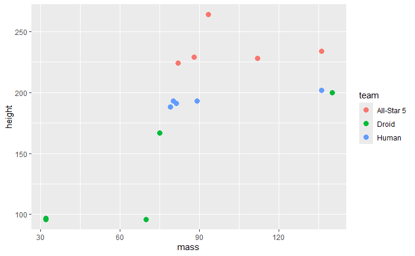

```r
starwars %>%
  select(name, species, height, mass) %>%
  filter(!is.na(height)) %>%     # remove any characters with missing height
  mutate(team=case_when(species == "Human" ~ "Human",   # create the 3 teams
                        species == "Droid" ~ "Droid",
                        T ~ "All-Star 5")) %>%
  group_by(species) %>%
  mutate(mass=ifelse(is.na(mass),  # for any characters missing mass use their species average
                     mean(mass, na.rm=T),
                     mass)) %>%
  ungroup() %>%
  mutate(mass=ifelse(is.na(mass),  # for any characters still missing mass use total avg
                     mean(mass, na.rm=T),
                     mass)) %>%
  arrange(team, desc(height), mass) %>% # sort by team, tallest - shortest and split any ties by lightest first
  group_by(team) %>%
  mutate(rank=row_number()) %>% # rank by tallest-shortest by team
  filter(rank<=5) %>%  # keep the top 5 as they will form our team
    ggplot(aes(x=mass, y=height, colour=team)) +     # Pass the pipeline to tidyverse plotting package ggplot2
      geom_point(size=3)  # Create a scatterplot of height and weight to get an idea of who might win
```

## Case Study: finding the outlier

task 1:It calculates the average and median mass of characters in the dataset, ignoring missing values.

```r
starwars %>%
  summarise(avg_mass=mean(mass, na.rm=T),
                     median_mass=median(mass, na.rm=T))
```

| avg_mass | median_mass |
| --- | --- |
| 97.31186 | 79 |

task 2:Displaying the outlier

[figure not shown]

```r
starwars %>%
  select(name, height, mass) %>%     # keep name, height and mass columns
  filter(!is.na(mass)) %>%                   # remove any rows with missing mass
  mutate(avg_mass=mean(mass),      # calculate the average mass for the data set
              SD_mass=sd(mass),            # calculate the standard deviation of mass for the data set
              outlier=ifelse(mass>(avg_mass+(3*SD_mass)),1,0)) %>%  # flag rows where mass > mean + 3xSD
  arrange(desc(outlier)) %>%            # sort the data set so the outlier is at the top
  ggplot(aes(x=height, y=mass)) +    # pass it to ggplot() to visualise the data
  geom_point(aes(colour = as.factor(-outlier)), size=3) +
  geom_text(aes(label=ifelse(outlier==1, as.character(name),'')), hjust=0.5, vjust=2) +
  theme(legend.position="none")
```

## Reshaping data with pivot from tidyr

task 1:Creating the data

```r
# Create some long data
starwars %>%
  filter(species %in% c("Human", "Kaminoan", "Twi'lek")) %>%
  group_by(species, sex) %>%
  summarise(avg_height= mean(height, na.rm=T))
```

| species | sex | avg_height |
| --- | --- | --- |
| Human | female | 163.5714 |
| Human | male | 182.3913 |
| Kaminoan | female | 213.0000 |
| Kaminoan | male | 229.0000 |
| Twi'lek | female | 178.0000 |
| Twi'lek | male | 180.0000 |

```r
# Add pivot_wider() to reshape the data
starwars %>%
  filter(species %in% c("Human", "Kaminoan", "Twi'lek")) %>%
  group_by(species, sex) %>%
  summarise(avg_height= mean(height, na.rm=T)) %>%
  pivot_wider(id_cols=species,
                      names_from=sex,
                      values_from=avg_height)
```

| species | female | male |
| --- | --- | --- |
| Human | 163.5714 | 182.3913 |
| Kaminoan | 213.0000 | 229.0000 |
| Twi'lek | 178.0000 | 180.0000 |

task 2:sorting the results by the number of missing values in descending order

```r
# Create some wide data
starwars %>%
  summarise(across(everything(), ~sum((is.na(.x)))))
```

| name | height | mass | hair_color | skin_color | eye_color | birth_year | sex | gender | homeworld | species | films | vehicles | starships |
| --- | --- | --- | --- | --- | --- | --- | --- | --- | --- | --- | --- | --- | --- |
| 0 | 6 | 28 | 5 | 0 | 0 | 44 | 4 | 4 | 10 | 4 | 0 | 0 | 0 |

```r
# Add pivot_longer()
starwars %>%
  summarise(across(everything(), ~sum((is.na(.x))))) %>%
  pivot_longer( cols=everything(),
                     names_to = "variable",
                     values_to = "number_of_missing") %>%
  arrange(desc(number_of_missing))
```

| variable | number_of_missing |
| --- | --- |
| birth_year | 44 |
| mass | 28 |
| homeworld | 10 |
| height | 6 |
| hair_color | 5 |
| sex | 4 |
| gender | 4 |
| species | 4 |
| name | 0 |
| skin_color | 0 |

[output cut: 4 more lines]